# ClassAssignment8

Ben Pelczynski

2024-07-25

```r
library(tidyverse)
```

```r
library(ggcorrplot)
library(car)
credit_data <- read.csv("credit_data.csv")
```

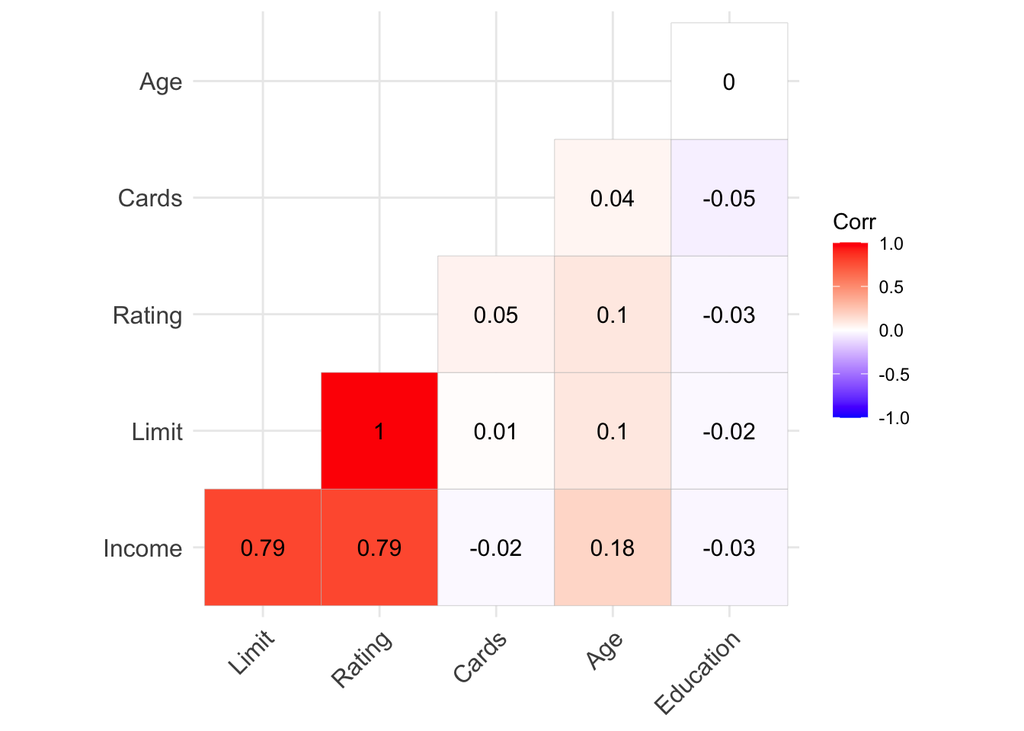

```r
cor_mat <- cor(credit_data[2:7])
ggcorrplot(cor_mat, lab=TRUE, type="lower")
```

Based on this matrix plot, there are issues of multicollinearity with Limit and Rating specifically having a 1-to-1 correlation (much greater than the threshold of 0.8).

```r
model <- lm(Balance~Income+Limit+Rating+Cards+Age+Education, data = credit_data)
vif(model)
```

```
##     Income      Limit     Rating      Cards        Age  Education
##   2.773276 228.848290 230.612596   1.433932   1.038541   1.008043
```

Based on this VIF statement, we will rebuild the model without Rating, the variable with the highest VIF.

```r
model <- lm(Balance~Income+Limit+Cards+Age+Education, data = credit_data)
vif(model)
```

```
##    Income     Limit     Cards       Age Education
##  2.759808  2.699771  1.007173  1.038539  1.003564
```

All VIFs fall into acceptable parameters in the the rebuilt model.

```r
new_data <- data.frame(Income = c(175, 48, 100, 134, 89),
                       Limit = c(9000, 2500, 5500, 10000, 7800),
                       Cards = c(2, 4, 7, 1, 6),
                       Age = c(33, 44, 68, 50, 100),
                       Education = c(18, 13, 15, 17, 19))
predict(model, newdata = new_data, interval = "prediction", level = .95)
```

```
##         fit        lwr       upr
## 1  675.3434  345.49118 1005.1955
## 2  -56.1092 -378.32548  266.1071
## 3  389.4078   63.20671  715.6090
## 4 1206.8888  882.28053 1531.4970
## 5 1032.3082  705.53063 1359.0858
```

We can say with a 95% level of confidence that a Balance, given the reasonable values I inserted, would fall between the lwr and upr limits given by the prediction model. For example, a 68-year old with 7 cards, a credit limit of 5500, an income of $100k, and an education level of 15, would have a balance between $63.21 and $715.61.

```r
predict(model, newdata = new_data, interval = "confidence", level = .95)
```

```
##         fit        lwr        upr
## 1  675.3434  595.74764  754.93909
## 2  -56.1092  -92.93787  -19.28053
## 3  389.4078  326.63685  452.17884
## 4 1206.8888 1153.00446 1260.77305
## 5 1032.3082  966.60733 1098.00910
```

We can say with a 95% level of confidence that the mean Balance of population, given the reasonable values I inserted, would fall between the lwr and upr limits given by the prediction model. For example, the population of a 68-year olds with 7 cards, a credit limit of 5500, an income of $100k, and an education level of 15, would have an average balance between $326.64 and $452.18.